# Project: Investigate a Dataset - TMDb Movie Data

- Introduction
- Data Wrangling
- Exploratory Data Analysis
- What are the top 20 actors with the highest profits?
- What are the top 20 actors with the the most appearances in movies?
- How many movies based on their genres were produced?
- What genre of movies have higher popularity?
- What are the top movies based on revenue, budget, popularity and average votes?
- Does movie runtime affect it adjusted revenue and budget?
- Conclusions
- Limitations
- Resources

## Introduction

### Dataset Description

The dataset is in a comma-seperated-values (.csv) format. The dataset contains 21 colums and 10866 rows. The columns in the dataset are; *id, imdb_id, popularity, budget, revenue original_title, cast, homepage, director, tagline, keywords, overview, runtime, genres, production_companies, release_date, vote_count, vote_average, release_year, budget_adj, revenue_adj.*

### Questions for Analysis

What are the top 20 actors with the highest profits?

What are the top 20 actors with the the most appearances in movies?

How many movies based on their genres were produced?

What genre of movies have higher popularity?

What are the top movies based on revenue, budget, popularity and average votes?

Does movie runtime affect it adjusted revenue and budget?

```python
#import statements
import pandas as pd
import numpy as np
import matplotlib.pyplot as plt
import seaborn as sns
% matplotlib inline
```

```python
# Upgrade pandas to use dataframe.explode() function.
!pip install --upgrade pandas==0.25.0

# Upgrade seaborn to use seaborn.histplot() function
!pip install -U seaborn
```

## Data Wrangling

#### Load data into pandas movie_dataframe

```python
# Load data to movie_df
movie_df = pd.read_csv('Database_TMDb_movie_data/tmdb-movies.csv')
```

#### Inspect first 5 rows of the data

```python
movie_df.head()
```

|  | id | imdb_id | popularity | budget | revenue | original_title | cast | homepage | director | tagline | ... | overview | runtime | genres | production_companies | release_date | vote_count | vote_average | release_year | budget_adj | revenue_adj |
| --- | --- | --- | --- | --- | --- | --- | --- | --- | --- | --- | --- | --- | --- | --- | --- | --- | --- | --- | --- | --- | --- |
| 0 | 135397 | tt0369610 | 32.985763 | 150000000 | 1513528810 | Jurassic World | Chris Pratt\|Bryce Dallas Howard\|Irrfan Khan\|Vi... | http://www.jurassicworld.com/ | Colin Trevorrow | The park is open. | ... | Twenty-two years after the events of Jurassic ... | 124 | Action\|Adventure\|Science Fiction\|Thriller | Universal Studios\|Amblin Entertainment\|Legenda... | 6/9/15 | 5562 | 6.5 | 2015 | 1.379999e+08 | 1.392446e+09 |
| 1 | 76341 | tt1392190 | 28.419936 | 150000000 | 378436354 | Mad Max: Fury Road | Tom Hardy\|Charlize Theron\|Hugh Keays-Byrne\|Nic... | http://www.madmaxmovie.com/ | George Miller | What a Lovely Day. | ... | An apocalyptic story set in the furthest reach... | 120 | Action\|Adventure\|Science Fiction\|Thriller | Village Roadshow Pictures\|Kennedy Miller Produ... | 5/13/15 | 6185 | 7.1 | 2015 | 1.379999e+08 | 3.481613e+08 |
| 2 | 262500 | tt2908446 | 13.112507 | 110000000 | 295238201 | Insurgent | Shailene Woodley\|Theo James\|Kate Winslet\|Ansel... | http://www.thedivergentseries.movie/#insurgent | Robert Schwentke | One Choice Can Destroy You | ... | Beatrice Prior must confront her inner demons ... | 119 | Adventure\|Science Fiction\|Thriller | Summit Entertainment\|Mandeville Films\|Red Wago... | 3/18/15 | 2480 | 6.3 | 2015 | 1.012000e+08 | 2.716190e+08 |
| 3 | 140607 | tt2488496 | 11.173104 | 200000000 | 2068178225 | Star Wars: The Force Awakens | Harrison Ford\|Mark Hamill\|Carrie Fisher\|Adam D... | http://www.starwars.com/films/star-wars-episod... | J.J. Abrams | Every generation has a story. | ... | Thirty years after defeating the Galactic Empi... | 136 | Action\|Adventure\|Science Fiction\|Fantasy | Lucasfilm\|Truenorth Productions\|Bad Robot | 12/15/15 | 5292 | 7.5 | 2015 | 1.839999e+08 | 1.902723e+09 |
| 4 | 168259 | tt2820852 | 9.335014 | 190000000 | 1506249360 | Furious 7 | Vin Diesel\|Paul Walker\|Jason Statham\|Michelle ... | http://www.furious7.com/ | James Wan | Vengeance Hits Home | ... | Deckard Shaw seeks revenge against Dominic Tor... | 137 | Action\|Crime\|Thriller | Universal Pictures\|Original Film\|Media Rights ... | 4/1/15 | 2947 | 7.3 | 2015 | 1.747999e+08 | 1.385749e+09 |

5 rows × 21 columns

#### Inspect last 5 rows of the data

```python
movie_df.tail()
```

|  | id | imdb_id | popularity | budget | revenue | original_title | cast | homepage | director | tagline | ... | overview | runtime | genres | production_companies | release_date | vote_count | vote_average | release_year | budget_adj | revenue_adj |
| --- | --- | --- | --- | --- | --- | --- | --- | --- | --- | --- | --- | --- | --- | --- | --- | --- | --- | --- | --- | --- | --- |
| 10861 | 21 | tt0060371 | 0.080598 | 0 | 0 | The Endless Summer | Michael Hynson\|Robert August\|Lord 'Tally Ho' B... | NaN | Bruce Brown | NaN | ... | The Endless Summer, by Bruce Brown, is one of ... | 95 | Documentary | Bruce Brown Films | 6/15/66 | 11 | 7.4 | 1966 | 0.000000 | 0.0 |
| 10862 | 20379 | tt0060472 | 0.065543 | 0 | 0 | Grand Prix | James Garner\|Eva Marie Saint\|Yves Montand\|Tosh... | NaN | John Frankenheimer | Cinerama sweeps YOU into a drama of speed and ... | ... | Grand Prix driver Pete Aron is fired by his te... | 176 | Action\|Adventure\|Drama | Cherokee Productions\|Joel Productions\|Douglas ... | 12/21/66 | 20 | 5.7 | 1966 | 0.000000 | 0.0 |
| 10863 | 39768 | tt0060161 | 0.065141 | 0 | 0 | Beregis Avtomobilya | Innokentiy Smoktunovskiy\|Oleg Efremov\|Georgi Z... | NaN | Eldar Ryazanov | NaN | ... | An insurance agent who moonlights as a carthie... | 94 | Mystery\|Comedy | Mosfilm | 1/1/66 | 11 | 6.5 | 1966 | 0.000000 | 0.0 |
| 10864 | 21449 | tt0061177 | 0.064317 | 0 | 0 | What's Up, Tiger Lily? | Tatsuya Mihashi\|Akiko Wakabayashi\|Mie Hama\|Joh... | NaN | Woody Allen | WOODY ALLEN STRIKES BACK! | ... | In comic Woody Allen's film debut, he took the... | 80 | Action\|Comedy | Benedict Pictures Corp. | 11/2/66 | 22 | 5.4 | 1966 | 0.000000 | 0.0 |
| 10865 | 22293 | tt0060666 | 0.035919 | 19000 | 0 | Manos: The Hands of Fate | Harold P. Warren\|Tom Neyman\|John Reynolds\|Dian... | NaN | Harold P. Warren | It's Shocking! It's Beyond Your Imagination! | ... | A family gets lost on the road and stumbles up... | 74 | Horror | Norm-Iris | 11/15/66 | 15 | 1.5 | 1966 | 127642.279154 | 0.0 |

5 rows × 21 columns

#### Dimension of the data

```python
movie_df.shape
```

```
(10866, 21)
```

The movie_df contains 10866 rows and 21 columns

#### Columns and their datatypes

```python
# More info about the columns and their datatypes
movie_df.info()
```

```
<class 'pandas.core.frame.DataFrame'>
RangeIndex: 10866 entries, 0 to 10865
Data columns (total 21 columns):
id                      10866 non-null int64
imdb_id                 10856 non-null object
popularity              10866 non-null float64
budget                  10866 non-null int64
revenue                 10866 non-null int64
original_title          10866 non-null object
cast                    10790 non-null object
homepage                2936 non-null object
director                10822 non-null object
tagline                 8042 non-null object
keywords                9373 non-null object
overview                10862 non-null object
runtime                 10866 non-null int64
genres                  10843 non-null object
production_companies    9836 non-null object
release_date            10866 non-null object
vote_count              10866 non-null int64
vote_average            10866 non-null float64
release_year            10866 non-null int64
budget_adj              10866 non-null float64
revenue_adj             10866 non-null float64
dtypes: float64(4), int64(6), object(11)
memory usage: 1.7+ MB
```

Some of the columns contain missing values and need to be dealt with before any analysis can be performed using the data. The data cleaning section documents systematically how these missing values will be dealt with.

### Data Cleaning

The Data Cleaning process will start with inspecting the data to reveal any duplicates or missing values if any. Then features that are not relevant to the objectives of the study will be droped or removed.

#### Check if there is any missing value in the dataset

```python
# Checking for missing values
movie_df.isnull().values.any()
```

```
True
```

The results show that there are some missing values in the dataset.

#### Columns with missing values

```python
movie_df.info()
```

```
<class 'pandas.core.frame.DataFrame'>
RangeIndex: 10866 entries, 0 to 10865
Data columns (total 21 columns):
id                      10866 non-null int64
imdb_id                 10856 non-null object
popularity              10866 non-null float64
budget                  10866 non-null int64
revenue                 10866 non-null int64
original_title          10866 non-null object
cast                    10790 non-null object
homepage                2936 non-null object
director                10822 non-null object
tagline                 8042 non-null object
keywords                9373 non-null object
overview                10862 non-null object
runtime                 10866 non-null int64
genres                  10843 non-null object
production_companies    9836 non-null object
release_date            10866 non-null object
vote_count              10866 non-null int64
vote_average            10866 non-null float64
release_year            10866 non-null int64
budget_adj              10866 non-null float64
revenue_adj             10866 non-null float64
dtypes: float64(4), int64(6), object(11)
memory usage: 1.7+ MB
```

#### Total number of missing values (NaN) in the dataset

```python
# Count all missing values in the dataset
movie_df.isnull().sum().sum()
```

```
13434
```

#### Drop some features

**Imbd id, homepage, director, tagline, keywords, summary, budget, and revenue** feature variables will be eliminated because they are unrelated to the study's goals.

```python
# Remove Features That are not relevant
movie_v1_df = movie_df.drop(['imdb_id','homepage', 'director','tagline','keywords','overview','budget','revenue'],axis=1)
```

```python
movie_v1_df.shape
```

```
(10866, 13)
```

After removing those features, the movie_df now contains 10866 rows and 13 columns

#### Check for duplicates

```python
# Checking for duplicates
movie_v1_df.duplicated().sum()
```

```
1
```

```python
# Check The duplicated movie
movie_v1_df[movie_v1_df.duplicated()]
```

|  | id | popularity | original_title | cast | runtime | genres | production_companies | release_date | vote_count | vote_average | release_year | budget_adj | revenue_adj |
| --- | --- | --- | --- | --- | --- | --- | --- | --- | --- | --- | --- | --- | --- |
| 2090 | 42194 | 0.59643 | TEKKEN | Jon Foo\|Kelly Overton\|Cary-Hiroyuki Tagawa\|Ian... | 92 | Crime\|Drama\|Action\|Thriller\|Science Fiction | Namco\|Light Song Films | 3/20/10 | 110 | 5.0 | 2010 | 30000000.0 | 967000.0 |

```python
# drop the duplicated movie
movie_v1_df.drop_duplicates(inplace = True)
```

From the above result, it is revealed that the movie_df contains 1 duplicate and that is **TEKKEN** and has been dropped

```python
# check the number of samples after droping the duplicates
movie_v1_df.shape
```

```
(10865, 13)
```

It is noted that the movie_df now has 10865 rows and 13 columns after eliminating the duplicate.

#### Check for missing values

```python
movie_v1_df.isnull().sum()
```

```
id                         0
popularity                 0
original_title             0
cast                      76
runtime                    0
genres                    23
production_companies    1030
release_date               0
vote_count                 0
vote_average               0
release_year               0
budget_adj                 0
revenue_adj                0
dtype: int64
```

Cast, genres, and production_companies all have missing values of 76, 23, and 1030 respectively.

```python
# Before i drop alll the NaNs in the dataset

# I will make a copy of the movie_v1_df and drop the NAs and to check the impact

copy_v1_df = movie_v1_df.copy()
copy_v1_df.shape

copy_v2_df = copy_v1_df.dropna()
copy_v2_df.shape

def prop(x,y):
    print('The percentage of rows that will be dropped is : {:.2f}'.format((x[0]/y[0])*100))

# Using the function to calculate the proportion of missing values
prop(copy_v2_df.shape,copy_v1_df.shape)
```

```
The percentage of rows that will be dropped is : 90.12
```

#### **NOTE** : The copy v1 and copy v2 dataframes, which were developed to support the debate on whether to remove the NaNs or replace them with unknowns, will be removed from this discussion.

```python
# replacing missing values with unknown
movie_v1_df.fillna('unknown', inplace=True)
movie_v1_df.isnull().sum()

# No Missing data
```

```
id                      0
popularity              0
original_title          0
cast                    0
runtime                 0
genres                  0
production_companies    0
release_date            0
vote_count              0
vote_average            0
release_year            0
budget_adj              0
revenue_adj             0
dtype: int64
```

The movie_v1_df will be saved in a new variable named clean_df after the data has been cleaned and all duplicates have been eliminated.

```python
clean_df = movie_v1_df

# Inspect the first five rows of the clean_df
clean_df.head()
```

|  | id | popularity | original_title | cast | runtime | genres | production_companies | release_date | vote_count | vote_average | release_year | budget_adj | revenue_adj |
| --- | --- | --- | --- | --- | --- | --- | --- | --- | --- | --- | --- | --- | --- |
| 0 | 135397 | 32.985763 | Jurassic World | Chris Pratt\|Bryce Dallas Howard\|Irrfan Khan\|Vi... | 124 | Action\|Adventure\|Science Fiction\|Thriller | Universal Studios\|Amblin Entertainment\|Legenda... | 6/9/15 | 5562 | 6.5 | 2015 | 1.379999e+08 | 1.392446e+09 |
| 1 | 76341 | 28.419936 | Mad Max: Fury Road | Tom Hardy\|Charlize Theron\|Hugh Keays-Byrne\|Nic... | 120 | Action\|Adventure\|Science Fiction\|Thriller | Village Roadshow Pictures\|Kennedy Miller Produ... | 5/13/15 | 6185 | 7.1 | 2015 | 1.379999e+08 | 3.481613e+08 |
| 2 | 262500 | 13.112507 | Insurgent | Shailene Woodley\|Theo James\|Kate Winslet\|Ansel... | 119 | Adventure\|Science Fiction\|Thriller | Summit Entertainment\|Mandeville Films\|Red Wago... | 3/18/15 | 2480 | 6.3 | 2015 | 1.012000e+08 | 2.716190e+08 |
| 3 | 140607 | 11.173104 | Star Wars: The Force Awakens | Harrison Ford\|Mark Hamill\|Carrie Fisher\|Adam D... | 136 | Action\|Adventure\|Science Fiction\|Fantasy | Lucasfilm\|Truenorth Productions\|Bad Robot | 12/15/15 | 5292 | 7.5 | 2015 | 1.839999e+08 | 1.902723e+09 |
| 4 | 168259 | 9.335014 | Furious 7 | Vin Diesel\|Paul Walker\|Jason Statham\|Michelle ... | 137 | Action\|Crime\|Thriller | Universal Pictures\|Original Film\|Media Rights ... | 4/1/15 | 2947 | 7.3 | 2015 | 1.747999e+08 | 1.385749e+09 |

## Exploratory Data Analysis

#### Summary statistics

```python
clean_df.describe()
```

|  | id | popularity | runtime | vote_count | vote_average | release_year | budget_adj | revenue_adj |
| --- | --- | --- | --- | --- | --- | --- | --- | --- |
| count | 10865.000000 | 10865.000000 | 10865.000000 | 10865.000000 | 10865.000000 | 10865.000000 | 1.086500e+04 | 1.086500e+04 |
| mean | 66066.374413 | 0.646446 | 102.071790 | 217.399632 | 5.975012 | 2001.321859 | 1.754989e+07 | 5.136900e+07 |
| std | 92134.091971 | 1.000231 | 31.382701 | 575.644627 | 0.935138 | 12.813260 | 3.430753e+07 | 1.446383e+08 |
| min | 5.000000 | 0.000065 | 0.000000 | 10.000000 | 1.500000 | 1960.000000 | 0.000000e+00 | 0.000000e+00 |
| 25% | 10596.000000 | 0.207575 | 90.000000 | 17.000000 | 5.400000 | 1995.000000 | 0.000000e+00 | 0.000000e+00 |
| 50% | 20662.000000 | 0.383831 | 99.000000 | 38.000000 | 6.000000 | 2006.000000 | 0.000000e+00 | 0.000000e+00 |
| 75% | 75612.000000 | 0.713857 | 111.000000 | 146.000000 | 6.600000 | 2011.000000 | 2.085325e+07 | 3.370173e+07 |
| max | 417859.000000 | 32.985763 | 900.000000 | 9767.000000 | 9.200000 | 2015.000000 | 4.250000e+08 | 2.827124e+09 |

The above table presents the summary statistics for some of the columns in the dataset.

**Popularity** : The minimum popularity recorded is 0.000065 whilst the maximum is 32.985 with a mean of 0.646 and a median of 0.383.

**Runtime** : The minimum movie runtime recorded is 0 whilst the maximum is 900 minutes with a mean of 102.07 minutes and a median of 99 minutes.

**Adjusted Revenue** : The minimum revenue recorded is 0 whilst the maximum is 282,7124000 with a mean of 51,369000.

**Adjusted Budget** : The minimum revenue recorded is 0 whilst the maximum is 425,000000 with a mean of 17,549890.

**Released Year** : The movies contained in this dataset has a released year from 1960 to 2015.

#### Scatter plots of all the features

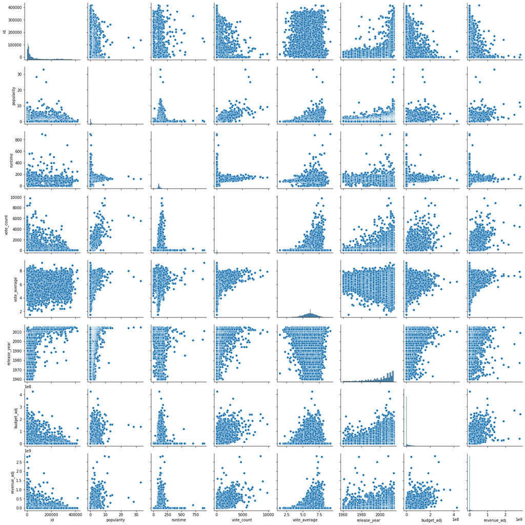

```python
plt.figure(figsize=[15,15]);
sns.pairplot(clean_df);
```

### Explore how the adjusted budget and adjusted revenue relates to profit

```python
#calculate the profit and add it to the clean_df as a new column

profit = clean_df['revenue_adj'] - clean_df['budget_adj']

 # add the newly created column to the clean_df
clean_df['profit'] = profit
```

```python
clean_df.head()
```

|  | id | popularity | original_title | cast | runtime | genres | production_companies | release_date | vote_count | vote_average | release_year | budget_adj | revenue_adj | profit |
| --- | --- | --- | --- | --- | --- | --- | --- | --- | --- | --- | --- | --- | --- | --- |
| 0 | 135397 | 32.985763 | Jurassic World | Chris Pratt\|Bryce Dallas Howard\|Irrfan Khan\|Vi... | 124 | Action\|Adventure\|Science Fiction\|Thriller | Universal Studios\|Amblin Entertainment\|Legenda... | 6/9/15 | 5562 | 6.5 | 2015 | 1.379999e+08 | 1.392446e+09 | 1.254446e+09 |
| 1 | 76341 | 28.419936 | Mad Max: Fury Road | Tom Hardy\|Charlize Theron\|Hugh Keays-Byrne\|Nic... | 120 | Action\|Adventure\|Science Fiction\|Thriller | Village Roadshow Pictures\|Kennedy Miller Produ... | 5/13/15 | 6185 | 7.1 | 2015 | 1.379999e+08 | 3.481613e+08 | 2.101614e+08 |
| 2 | 262500 | 13.112507 | Insurgent | Shailene Woodley\|Theo James\|Kate Winslet\|Ansel... | 119 | Adventure\|Science Fiction\|Thriller | Summit Entertainment\|Mandeville Films\|Red Wago... | 3/18/15 | 2480 | 6.3 | 2015 | 1.012000e+08 | 2.716190e+08 | 1.704191e+08 |
| 3 | 140607 | 11.173104 | Star Wars: The Force Awakens | Harrison Ford\|Mark Hamill\|Carrie Fisher\|Adam D... | 136 | Action\|Adventure\|Science Fiction\|Fantasy | Lucasfilm\|Truenorth Productions\|Bad Robot | 12/15/15 | 5292 | 7.5 | 2015 | 1.839999e+08 | 1.902723e+09 | 1.718723e+09 |
| 4 | 168259 | 9.335014 | Furious 7 | Vin Diesel\|Paul Walker\|Jason Statham\|Michelle ... | 137 | Action\|Crime\|Thriller | Universal Pictures\|Original Film\|Media Rights ... | 4/1/15 | 2947 | 7.3 | 2015 | 1.747999e+08 | 1.385749e+09 | 1.210949e+09 |

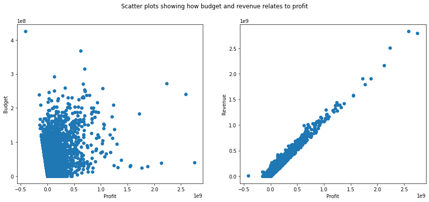

```python
# Explore the relationship using scatter plots

fig, ax = plt.subplots(1,2,figsize=(15,6))

fig.suptitle('Scatter plots showing how budget and revenue relates to profit')

plt.subplot(1,2,1)
plt.scatter(clean_df['profit'],clean_df['budget_adj']);
plt.xlabel('Profit')
plt.ylabel('Budget')

plt.subplot(1,2,2)
plt.scatter(clean_df['profit'],clean_df['revenue_adj']);
plt.xlabel('Profit')
plt.ylabel('Revenue')
```

The plots above show that profit and adjusted revenue are highly and positively correlated. This means that movies with higher revenues tend to give higher profits.

Also, the relationship between profit and adjusted budget is also positive, but a weaker one. From the plot, it can be noticed that huge budgeted movies tend to give higher profits.

### Research Question 1 - Top 20 actors with the highest profits

```python
cast_df = clean_df.assign(cast=clean_df['cast'].str.split('|')).explode('cast')
```

```python
profit_by_cast = cast_df.groupby('cast')['profit'].mean()
```

```python
# Top 20 casts with the highest profit
top_20_df = profit_by_cast.sort_values(ascending=False).head(20)
```

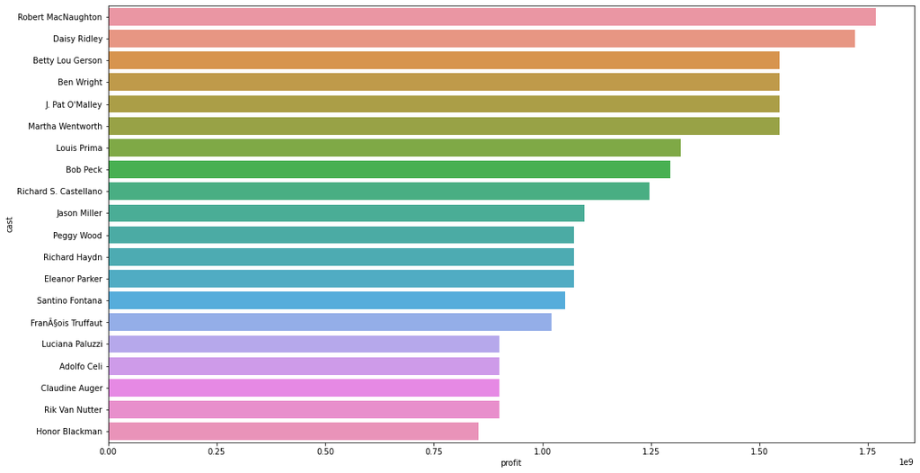

```python
# Graphing
plt.figure(figsize=[18,10])
sns.barplot(x=top_20_df, y=top_20_df.index);
```

The above graph shows that Robert MacNaughton is the actor with the highest profit, closely followed by Daisy Ridley and Betty Lou Gerson, while Honor Blackman became the last actor.

### Research Question 2 - Top 20 actors with the most appearances in movies

```python
#Top 20 Actors with the highest appearance in movies
cast_by_app = cast_df['cast'].value_counts()
```

```python
# Drop the unknown row
cast_by_app.drop('unknown', inplace=True)
```

```python
# Get the top 20 actors with the most appearnce
top_20 = cast_by_app.sort_values(ascending=False).head(20)
```

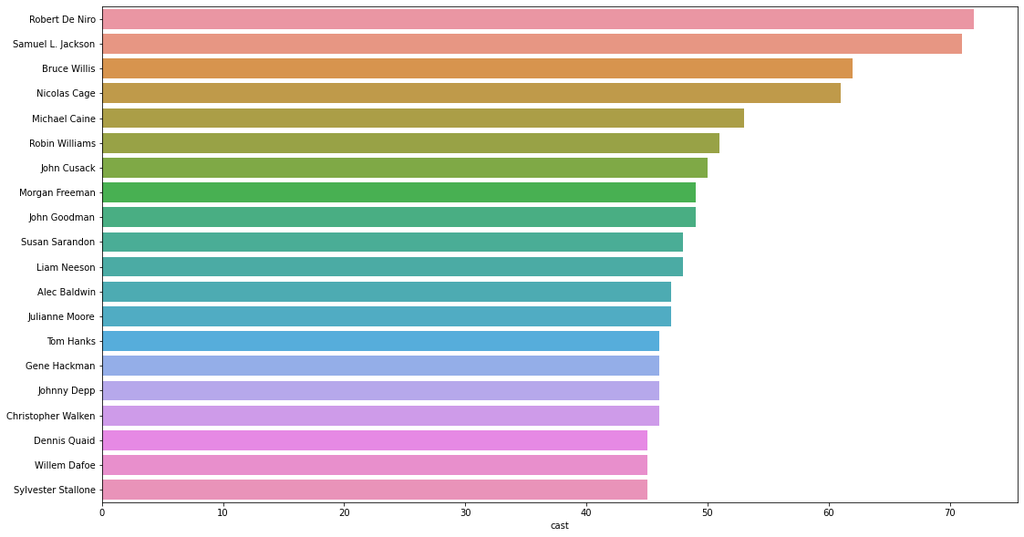

```python
# Plot The Graph
plt.figure(figsize=[18,10])
sns.barplot(x=top_20,y=top_20.index);
```

### Research Question 3 - How many movies based on their genres were produced

```python
# Explode the genres column
genre_df = clean_df.assign(genres=clean_df['genres'].str.split('|')).explode('genres')

# Total number of rows after exploding the genres column
genre_df.shape
```

```
(26978, 14)
```

```python
# Count number of movies that belongs to each genre
per_genre = genre_df['genres'].value_counts()

# Drop the unknown genre which was created to represent missing values
per_genre.drop('unknown', inplace=True)
```

[figure not shown]

```python
# Graping
plt.figure(figsize=[18,10])
sns.barplot(x=per_genre,y=per_genre.index);
plt.title('Top 10 movie genres with highest popularity')
plt.xlabel('Popularity')
plt.ylabel('Genres')
```

### Research Question 4 - What genre of movies have higher popularity

```python
# Group by genres and get the mean of the popularity
popularity_by_genre = genre_df.groupby('genres')['popularity'].mean()
```

```python
# Top 10 genres based on popularity
top_10_genres = popularity_by_genre.sort_values(ascending=False).head(10)
```

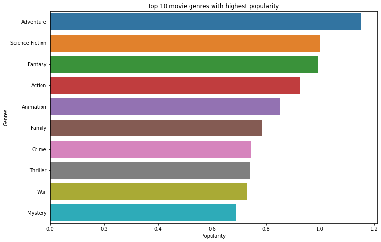

```python
# Ploting the graph
plt.figure(figsize=[12,8])
sns.barplot(x=top_10_genres, y=top_10_genres.index);
plt.title('Top 10 movie genres with highest popularity')
plt.xlabel('Popularity')
plt.ylabel('Genres')
```

From the bar plot above, the most popular genre of movie based on the dataset is Aventure, followed by Science Fiction, Fantasy and Action.

### Research Question 5 - Top Movies based on Revenue, Budget, Popularity and Average Votes

Moving on to other TMDb dataset features It would be crucial to learn which films received the most money, attention, and votes. Let's now determine the top 10 movies based on these characteristics.

- #### 5.1: Top Movies based on their revenue The following code snippet produce the barplot representing the top 10 movies based on their adjusted revenue.

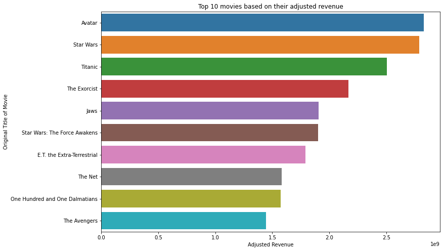

```python
top_10 = clean_df.loc[:, ['original_title','revenue_adj']].sort_values(by='revenue_adj', ascending=False).head(10)
plt.figure(figsize=[12,8])
sns.barplot(x=top_10['revenue_adj'], y=top_10['original_title']);
plt.title('Top 10 movies based on their adjusted revenue')
plt.xlabel('Adjusted Revenue')
plt.ylabel('Original Title of Movie')
```

- #### 5.2: Top Movies based on their budget The code below produce the barplot representing the top 10 movies based on their adjusted budget.

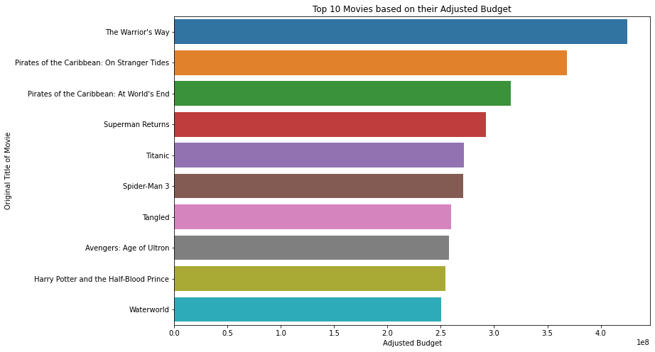

```python
top_10 = clean_df.loc[:, ['original_title','budget_adj']].sort_values(by='budget_adj', ascending=False).head(10)
plt.figure(figsize=[12,8])
sns.barplot(x=top_10['budget_adj'], y=top_10['original_title']);
plt.title('Top 10 Movies based on their Adjusted Budget')
plt.xlabel('Adjusted Budget')
plt.ylabel('Original Title of Movie')
```

- #### 5.3: Top Movies based on their popularity The code below produce the barplot representing the top 10 movies based on their popularity.

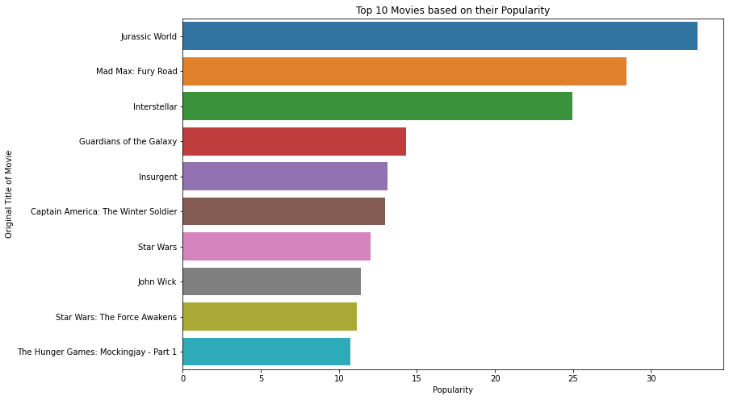

```python
top_10 = clean_df.loc[:, ['original_title','popularity']].sort_values(by='popularity', ascending=False).head(10)
plt.figure(figsize=[12,8])
sns.barplot(x=top_10['popularity'], y=top_10['original_title']);
plt.title('Top 10 Movies based on their Popularity')
plt.xlabel('Popularity')
plt.ylabel('Original Title of Movie')
```

- #### 5.3: Top Movies based on their average votes The code below produce the barplot representing the top 10 movies based on their average votes.

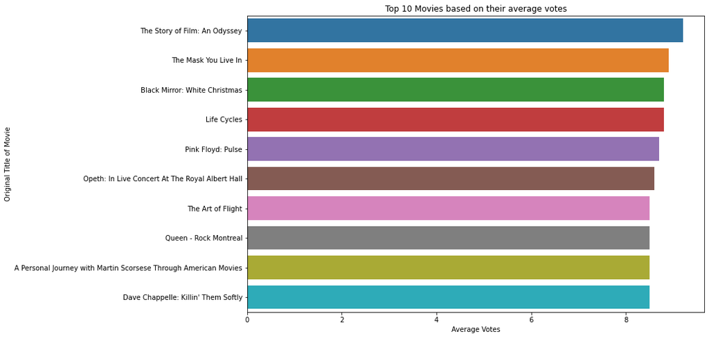

```python
top_10 = clean_df.loc[:, ['original_title','vote_average']].sort_values(by='vote_average', ascending=False).head(10)
plt.figure(figsize=[12,8])
sns.barplot(x=top_10['vote_average'], y=top_10['original_title']);
plt.title('Top 10 Movies based on their average votes')
plt.xlabel('Average Votes')
plt.ylabel('Original Title of Movie')
```

Based on the plots above, it can be shown that, the movie **Avatar** is ranked first in terms of revenue, **The Worrior's Way** is the movie with the highest budget, the **Jurassic World** is the most popular movie and **The Story of Film: An Odyssey** is the movie with the highest average votes.

### Research Question 6 - How does movie runtime affect it adjusted revenue and budget

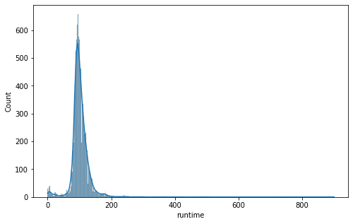

```python
# Ploting the distribution of the runtime variable
plt.figure(figsize=[8,5])
sns.histplot(data=clean_df, x="runtime", kde=True);
```

```python
# Summary Statistics of the runtime variable
clean_df['runtime'].describe()
```

```
count    10865.000000
mean       102.071790
std         31.382701
min          0.000000
25%         90.000000
50%         99.000000
75%        111.000000
max        900.000000
Name: runtime, dtype: float64
```

#### Scatter plot of runtime, revenue and budget

```
 - The correlation coefficient associated  with movie runtime and adjusuted revenue is: 0.18
 - The correlation coefficient associated  with movie runtime and adjusuted budget is: 0.22
```

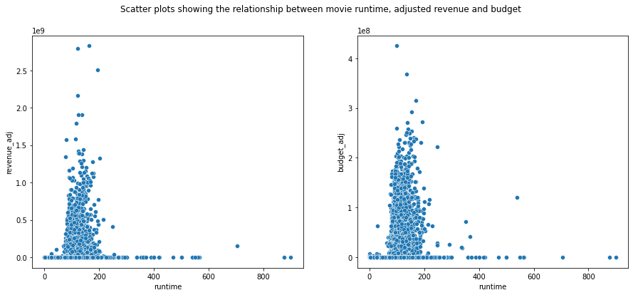

```python
fig, ax = plt.subplots(1,2,figsize=(15,6))

fig.suptitle('Scatter plots showing the relationship between movie runtime, adjusted revenue and budget')

plt.subplot(1,2,1)
sns.scatterplot(x='runtime', y='revenue_adj', data=clean_df);


plt.subplot(1,2,2)
sns.scatterplot(x='runtime', y='budget_adj', data=clean_df);

# Runtime and Adjusted budget correlation coefficient
r_b_corr = np.corrcoef(x=clean_df['runtime'], y=clean_df['budget_adj'])

# Runtime and Adjusted revenue correlation coefficient
r_r_corr = np.corrcoef(x=clean_df['runtime'], y=clean_df['revenue_adj'])

print(' - The correlation coefficient associated  with movie runtime and adjusuted revenue is: {:.2f}'.format(r_r_corr[0,1]))
print(' - The correlation coefficient associated  with movie runtime and adjusuted budget is: {:.2f}'.format(r_b_corr[0,1]))
```

Based on the scatter plots produced above and the correlation coefficient computed, the scatter plots show a positive but weak correlation between movie runtime and the adjusted budget with a correlation coefficient of 0.22. This relationship implies that, on average, more budgeted movies have longer running times. The observation is true because more budget can be assumed to be spent on making extra footage.

## Limitations

After Investigating the Dataset, the following limitation was uncovered:

It is important to point out that we had films with a duration of 0 and an adjusted budget and revenue of 0 respectively. The number of data points would have been cut in half if these zeros had been removed from the dataset.

## Resources

https://michaelcurrin.github.io/dev-cheatsheets/cheatsheets/markdown/

https://seaborn.pydata.org/tutorial.html

Documentation for python, numpy, pandas and matplotlib

https://www.ibm.com/docs/ro/spss-modeler/18.0.0?topic=data-writing-description-report

https://stackoverflow.com/questions/44885933/how-to-sort-bars-in-a-bar-plot-in-ascending-order

https://www.edureka.co/blog/wp-content/uploads/2018/10/Jupyter_Notebook_CheatSheet_Edureka.pdf

```python
from subprocess import call
call(['python', '-m', 'nbconvert', 'Investigate_a_Dataset.ipynb'])
```

```
0
```